# RLMS

Ляпина Екатерина

Wednesday, April 15, 2015

```r
h <- subset(h_old, select=c(rj13.2 , rh6, r_int_y,  rh5, r_diplom, status, rj161.3y))
rm(h_old)
h <- na.omit(h)
h <- rename(h, c(rj13.2="payroll", rh6 = "birth", r_int_y = "age", rh5 = "sex", r_diplom = "education",  rj161.3y = "experience"))
h$age <- h$age - h$birth
h$birth <- NULL

saveRDS(h, file = "r22i_os25a.RDS") # сохраняем всё ценное в файл
h <- readRDS("r22i_os25a.RDS") # читаем из файла что там есть

for (i in 1:nrow(h)) h[i,7]  = ifelse((h[i,4]=="окончил 0 - 6 классов") || (h[i,5]=="незаконч среднее образование (7 - 8 кл)")|| (h[i,5]=="незаконч среднее образование (7 - 8 кл) + что-то еще"), 1, 0)
for (i in 1:nrow(h)) h[i,8]  = ifelse(h[i,4]=="законч среднее образование", 1, 0)
for (i in 1:nrow(h)) h[i,9]  = ifelse(h[i,4]=="законч среднее специальное образование", 1, 0)
for (i in 1:nrow(h)) h[i,10]  = ifelse(h[i,4]=="законч высшее образование и выше", 1, 0)
h <- rename(h, c(V7 ="ed_1", V8= "ed_2", V9 = "ed_3",  V10 = "ed_4"))

for (i in 1:nrow(h)) h[i,11]  = ifelse(h[i,5]=="областной центр ", 1, 0)
for (i in 1:nrow(h)) h[i,12]  = ifelse(h[i,5]=="город", 1, 0)
for (i in 1:nrow(h)) h[i,13]  = ifelse(h[i,5]=="ПГТ", 1, 0)
for (i in 1:nrow(h)) h[i,14]  = ifelse(h[i,5]=="село", 1, 0)
h <- rename(h, c(V11 = "st_1", V12 = "st_2", V13 = "st_3",  V14 = "st_4"))

for (i in 1:nrow(h)) h[i,15]  = ifelse(h[i,3]=="МУЖСКОЙ", 1, 0)
for (i in 1:nrow(h)) h[i,16]  = ifelse(h[i,3]=="ЖЕНСКИЙ", 1, 0)
h <- rename(h, c(V15 = "male", V16 = "female"))
h$status <- NULL
h$education <- NULL
h$sex <- NULL
```

**Объектом исследования** являются данные Российского мониторинга экономического положения и здоровья населения (РМЭЗ, он же RLMS), относящиеся к индивидам.

**Предметом исследования** выступают причинно-следственные связи и зависимости показателей.

**Цель работы:**

Выявление факторов, влияющих на размер заработной платы. Установление структурных связей и закономерностей между элементами исследуемой системы в выбранной предметной области. Последующая интерпретация имеющихся данных, анализ применимости полученных результатов.

**Задачи:**

Прохождение этапов извлечения, очистки и трансформации сырых данных. Практическая задача сводится к необходимости выявления, в какой степени какие факторы влияют на размер заработной платы и почему.

# Описание данных:

В нашем итоговом наборе данных 5678 наблюдений. Исходный файл с данными в формате sav.

### Описание исходных переменных:

- **rj13.2** : Заработная плата на основе опроса.
- **rh6** : Год рождения респондента.
- **r_int_y** : Год проведения опроса.
- **rh5** : Пол (создано 2 фиктивные переменные).
- **r_diplom** : Образование (создано 4 фиктивные переменные).
- **status** : Тип населенного пункта - размер населенного пункта может влиять положительно на средний уровень зарплат в нем (создано 4 фиктивные переменные).
- **rj161.3y** : Трудовой стаж в годах на момент опроса (стаж может влиять на заработную плату положительно).

Описательная статистика по нашим переменным:

```r
knitr::kable(summary(h))
```

|  | payroll | age | experience | ed_1 | ed_2.V1 | ed_3.V1 | ed_4.V1 | st_1.V1 | st_2.V1 | st_3.V1 | st_4.V1 | male.V1 | female.V1 |
| --- | --- | --- | --- | --- | --- | --- | --- | --- | --- | --- | --- | --- | --- |
|  | Min. : 0 | Min. :17.0 | Min. : 0.0 | Min. :0.0000000 | Min. :0.0000000 | Min. :0.0000000 | Min. :0.0000000 | Min. :0 | Min. :0.000000 | Min. :0.0000000 | Min. :0.0000000 | Min. :0.0000000 | Min. :0.0000000 |
|  | 1st Qu.: 10000 | 1st Qu.:32.0 | 1st Qu.: 9.0 | 1st Qu.:0.0000000 | 1st Qu.:0.0000000 | 1st Qu.:0.0000000 | 1st Qu.:0.0000000 | 1st Qu.:0 | 1st Qu.:0.000000 | 1st Qu.:0.0000000 | 1st Qu.:0.0000000 | 1st Qu.:0.0000000 | 1st Qu.:0.0000000 |
|  | Median : 16000 | Median :42.0 | Median :20.0 | Median :0.0000000 | Median :0.0000000 | Median :0.0000000 | Median :0.0000000 | Median :0 | Median :0.000000 | Median :0.0000000 | Median :0.0000000 | Median :0.0000000 | Median :1.0000000 |
|  | Mean : 19804 | Mean :42.4 | Mean :20.2 | Mean :0.0007045 | Mean :0.3099683 | Mean :0.2759775 | Mean :0.3289891 | Mean :0 | Mean :0.284255 | Mean :0.0581191 | Mean :0.2361747 | Mean :0.4489257 | Mean :0.5510743 |
|  | 3rd Qu.: 25000 | 3rd Qu.:52.0 | 3rd Qu.:30.0 | 3rd Qu.:0.0000000 | 3rd Qu.:1.0000000 | 3rd Qu.:1.0000000 | 3rd Qu.:1.0000000 | 3rd Qu.:0 | 3rd Qu.:1.000000 | 3rd Qu.:0.0000000 | 3rd Qu.:0.0000000 | 3rd Qu.:1.0000000 | 3rd Qu.:1.0000000 |
|  | Max. :250000 | Max. :87.0 | Max. :63.0 | Max. :1.0000000 | Max. :1.0000000 | Max. :1.0000000 | Max. :1.0000000 | Max. :0 | Max. :1.000000 | Max. :1.0000000 | Max. :1.0000000 | Max. :1.0000000 | Max. :1.0000000 |

Стандартное отклонение по количественным переменным: - **payroll** : 1.532050810^{4} - **age** : 12.549737 - **experience**: 12.9854927

Построим гистограмму переменной payroll (доход):

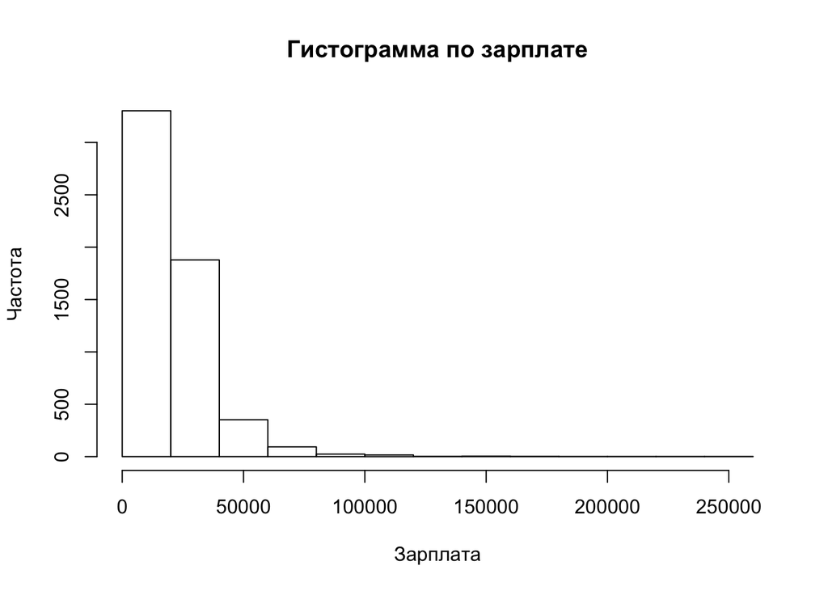

```r
hist(h$payroll, right=FALSE, xlab="Зарплата", ylab="Частота", main="Гистограмма по зарплате")
```

Построим гистограмму переменной age (возраст):

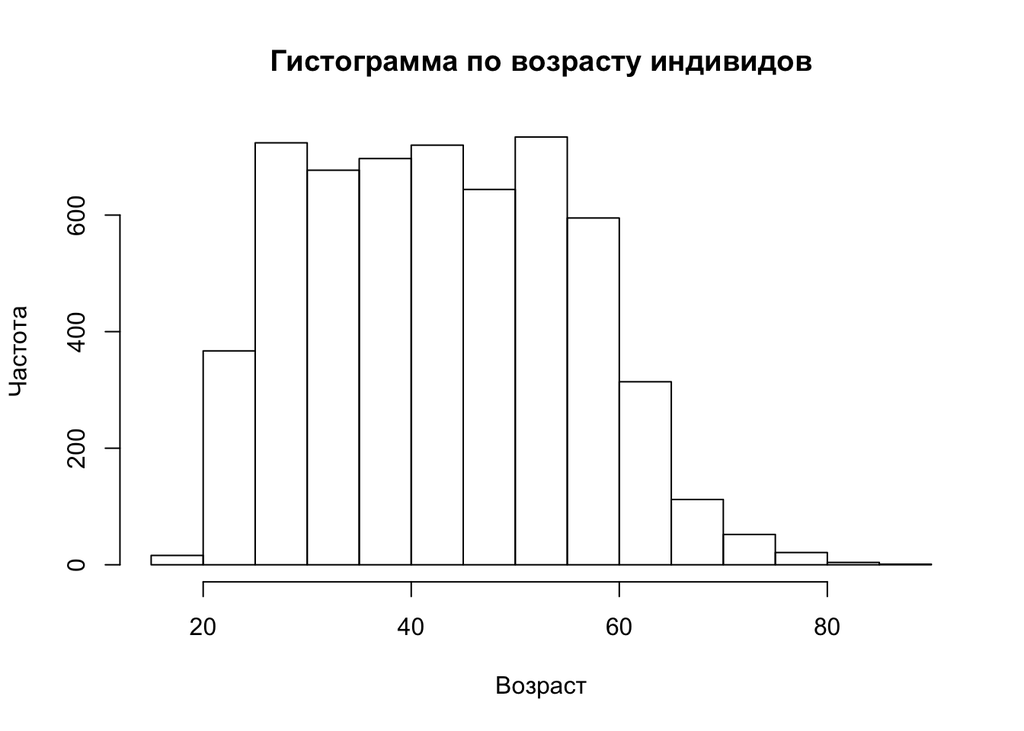

```r
hist(h$age, right=FALSE, xlab="Возраст", ylab="Частота", main="Гистограмма по возрасту индивидов")
```

Построим простую линейную регрессию заработной платы на возраст (**age**), пол (по фиктивной перменной **male**), 3 фиктивные переменные на образование (за базовую категорию возьмем самый низкий уровень образования: **ed_2**, **ed_3**, **ed_4**), 3 фиктивные переменные на тип населенного пунта (за базовую возьмем первую переменную: **st_2**, **st_3**, **st_4**) и стаж работы (**experience**). Основные характеристики модели:

```r
model <- lm(payroll ~ age + male + ed_2 + ed_3 + ed_4 + st_2  + st_3  + st_4 + experience, data=h)
summary(model)
```

```
##
## Call:
## lm(formula = payroll ~ age + male + ed_2 + ed_3 + ed_4 + st_2 +
##     st_3 + st_4 + experience, data = h)
##
## Residuals:
##    Min     1Q Median     3Q    Max
## -30581  -7840  -2474   4390 229251
##
## Coefficients:
##             Estimate Std. Error t value Pr(>|t|)
## (Intercept) 19896.37    1293.74  15.379  < 2e-16 ***
## age          -206.61      42.71  -4.838 1.35e-06 ***
## male         8199.40     382.89  21.415  < 2e-16 ***
## ed_2         2153.80     722.21   2.982  0.00287 **
## ed_3         4510.17     737.14   6.119 1.01e-09 ***
## ed_4        10322.22     729.75  14.145  < 2e-16 ***
## st_2        -3205.50     452.52  -7.084 1.57e-12 ***
## st_3        -3219.65     822.47  -3.915 9.16e-05 ***
## st_4        -7283.20     486.15 -14.981  < 2e-16 ***
## experience    123.65      41.31   2.993  0.00277 **
## ---
## Signif. codes:  0 '***' 0.001 '**' 0.01 '*' 0.05 '.' 0.1 ' ' 1
##
## Residual standard error: 14000 on 5668 degrees of freedom
## Multiple R-squared:  0.1665, Adjusted R-squared:  0.1652
## F-statistic: 125.8 on 9 and 5668 DF,  p-value: < 2.2e-16
```

Построим простую линейную регрессию с робастными ошибками заработной платы на возраст (**age**), пол (по фиктивной перменной **male**), 3 фиктивные переменные на образование (за базовую категорию возьмем самый низкий уровень образования: **ed_2**, **ed_3**, **ed_4**), 3 фиктивные переменные на тип населенного пунта (за базовую возьмем первую переменную: **st_2**, **st_3**, **st_4**) и стаж работы (**experience**). Основные характеристики модели:

```r
model2 <- rlm(payroll ~ age + male + ed_2 + ed_3 + ed_4 + st_2  + st_3  + st_4 + experience, data=h)
summary(model2)
```

```
##
## Call: rlm(formula = payroll ~ age + male + ed_2 + ed_3 + ed_4 + st_2 +
##     st_3 + st_4 + experience, data = h)
## Residuals:
##      Min       1Q   Median       3Q      Max
## -26573.3  -5949.1   -954.2   6068.3 231436.5
##
## Coefficients:
##             Value      Std. Error t value
## (Intercept) 20038.0436   877.1067    22.8456
## age          -210.6479    28.9524    -7.2757
## male         6811.2190   259.5826    26.2391
## ed_2         1773.7326   489.6288     3.6226
## ed_3         3424.4321   499.7500     6.8523
## ed_4         7667.7200   494.7447    15.4983
## st_2        -3416.2276   306.7929   -11.1353
## st_3        -2888.1727   557.6041    -5.1796
## st_4        -6171.5315   329.5937   -18.7247
## experience    117.9055    28.0076     4.2098
##
## Residual standard error: 8887 on 5668 degrees of freedom
```